# SFS adn Pi from Single Read Sampling

## 2.3 Correlation analysis

```r
#pops<-c("TB91","TB96","TB06","TB17","PWS91","PWS96","PWS07","PWS17","SS96","SS06","SS17","BC17","WA17","CA17")
year<-c(1991,1996,2006,2017,1991,1996,2007,2017,1996,2006,2017,2017,2017,2017)

#coverage info
byPopYr<-read.csv("../Output/QC/Bam_metrics_summary.csv", row.names = 1)
colnames(byPopYr)<-c("pop.yr","depth")
# mean pi from ANGSD
data<-merge(byPopYr, means, by="pop.yr")

#mean Ho
he<-read.csv("../Output/SingleRead/Het_mean.csv")
data<-merge(data, he, by="pop.yr")

#Tajima's D
tajimaD <- aggregate(Tajima ~ pop.yr,full, mean)
data<-merge(data, tajimaD, by="pop.yr")
write.csv(data, "../Output/SingleRead/Pi_He_Depth_summary_byPop.csv", row.names = F)


cor.test(data$depth, data$pi, method = "spearman")
#S = 210, p-value = 0.04999
#alternative hypothesis: true rho is not equal to 0
#sample estimates:
#      rho
#0.5384615

cor.test(data$depth, data$meanHe, method = "spearman")
#S = 176, p-value = 0.02247
#alternative hypothesis: true rho is not equal to 0
#sample estimates:
#      rho
#0.6131868

cor.test(data$depth, data$Tajima, method = "spearman")
#S = 532, p-value = 0.5629
#alternative hypothesis: true rho is not equal to 0
#sample estimates:
#       rho
#-0.1692308


data$pop<-factor(data$pop, levels=c("TB","PWS","SS", "BC","WA","CA"))
ggplot(data, aes(x=depth, y=pi, color=pop))+
    geom_point(size=3)+
    xlab("Mean read depth")+
    ylab(expression(paste("Mean ", pi)))+
    theme_bw()+
    annotate('text', x=1.28, y=0.00325, label="rho = 0.54*", size=3)+
    scale_color_manual(values=cols)+ theme(legend.title = element_blank())
ggsave("../Output/SingleRead/Correlation_depth.vs.Pi.png", width = 5.2, height = 4, dpi=300)


ggplot(data, aes(x=depth, y=meanHe,color=pop))+
    geom_point(size=3)+
    xlab("Mean read depth")+
    ylab("Mean He")+
    theme_bw()+  scale_color_manual(values=cols)+
    annotate('text', x=1.28, y=0.0041, label="rho = 0.61*", size=3)+
    theme(legend.title = element_blank())
ggsave("../Output/SingleRead/Correlation_depth.vs.He.png", width = 5.2, height = 4, dpi=300)
```

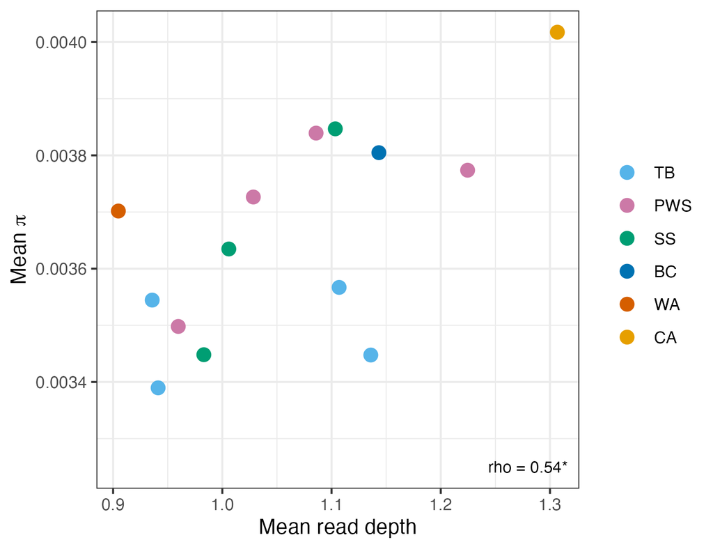

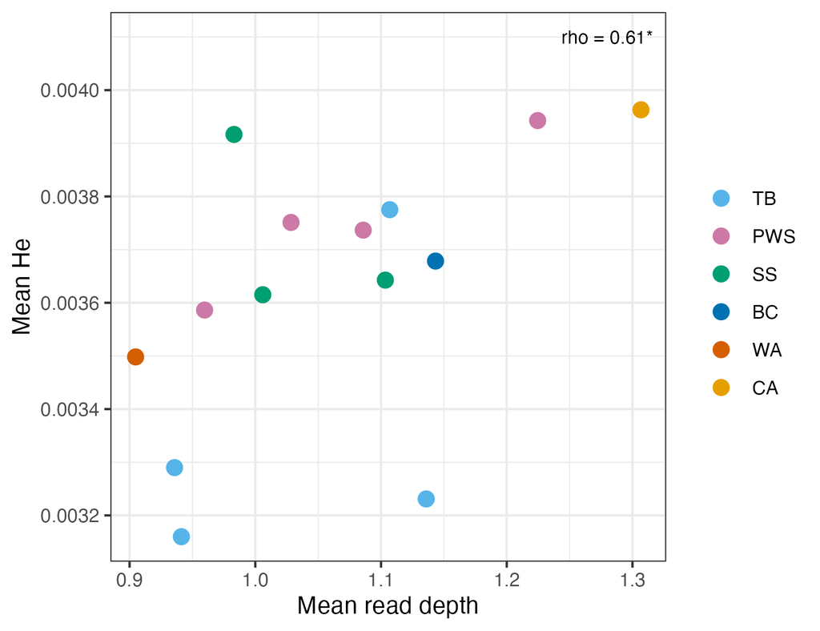

# 3 Plot SFS

```r
pops_info<-read.csv("../Data/Sample_metadata_892pops.csv")
popn<-data.frame(table(pops_info$Population.Year))


sfs1D<-data.frame()
for (i in 1:length(pops)){
    sfs <- scan(paste0("../Data/IBS/SFS/",pops[i],"_unfolded.sfs"))
    sfs1 <- data.frame(ac=sfs)
    sfs1$count<-0:(nrow(sfs1)-1)
    #remove the invariable sites
    sfs1<-sfs1[-c(1,nrow(sfs1)),]
    sfs1$pop<-pops[i]
    sfs1D<-rbind(sfs1D, sfs1)
}

sfs1D$pop<-factor(sfs1D$pop, levels=pops)
ggplot(data=sfs1D, aes(x=count, y=ac))+
    facet_wrap(~pop, ncol=4)+
        geom_bar(stat="identity", color="gray")+xlab("Frequency bin")+ ylab("Number of alleles")+
        theme_bw()+
        scale_y_continuous(labels=scales::comma)+
        theme(panel.grid.major.x = element_blank(),panel.grid.minor.x = element_blank(), panel.grid.minor.y = element_blank(), panel.grid.major.y = element_line(size=0.3))
ggsave("../Output/SingleRead/1DSFS_IBS_fromBam.png", width = 8, height = 5.5, dpi=300)


# calculated with doIBS files with SNP p=val cutoff
sfiles<-list.files("../Output/SingleRead/", pattern = "SFS_.+.csv")
SFS<-data.frame()
for(i in 1:length(sfiles)){
    df<-read.csv(paste0("../Output/SingleRead/", sfiles[i]), row.names = 1)

    popname<-gsub("SFS_",'',sfiles[i])
    popname<-gsub(".csv","",popname)
    #sample size per pop
    samplen<-popn$Freq[popn$Var1==popname]
    #remove invariant sites
    df<-df[!(df$Var1 %in% c(0, samplen)),]

    df$pop<-popname
    SFS<-rbind(SFS,df)
}

SFS$pop<-factor(SFS$pop,levels=c("TB91","TB96","TB06","TB17","PWS91","PWS96","PWS07","PWS17","CA17"))
ggplot(SFS, aes(x=Var1, y=Freq))+
    facet_wrap(~pop,ncol=4)+
    geom_bar(stat="identity", color="gray")+
    xlab("Frequency")+ ylab("Number of alleles")+
    theme_bw()+
    scale_y_continuous(labels=scales::comma)+
    theme( panel.grid.major.x = element_blank(),panel.grid.minor.x = element_blank())
ggsave("../Output/SingleRead/SFS_populations.year.png", width = 8, height = 5.5, dpi=300)
```

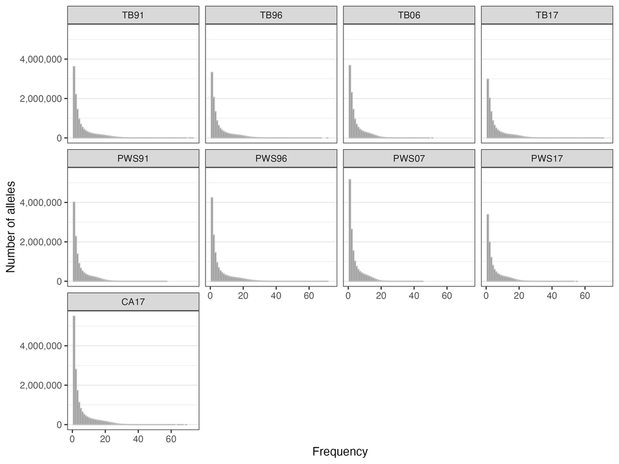

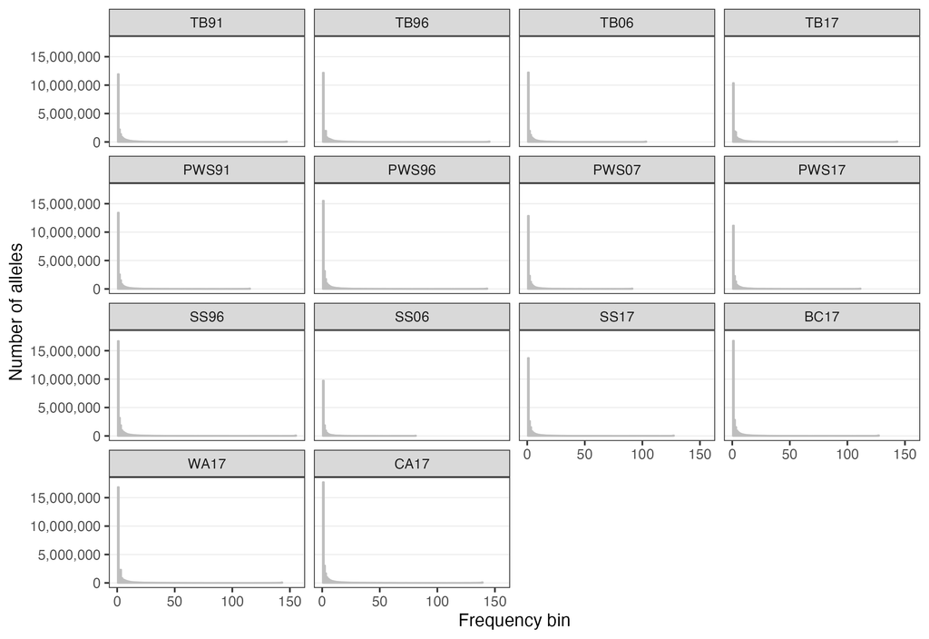

# 4 Compare Mafs.gz file from -doIBS run and -doSaf run for PWS17

- 1. -> angsd -bam /home/ktist/ph/data/angsd/samples/PWS17.txt -minMapQ 30 -minQ 20 -GL 2 -doMajorMinor 1 -doMaf 1 -SNP_pval 2e-6 -doIBS 1 -doCounts 1 -doCov 1 -makeMatrix 1 -minMaf 0 -P 24 -out /home/ktist/ph/data/angsd/single_read/PWS17  
     File size was 229.3Mb
- 2. -> angsd -bam /home/ktist/ph/data/angsd/samples/PWS17.txt -doSaf 1 -doMajorMinor 1 -GL 2 -doMaf 1 -doCounts 1 -doGlf 3 -doIBS 1 -SNP_pval 2e-6 -anc /home/jamcgirr/ph/data/c_harengus/c.harengus.fa -ref /home/jamcgirr/ph/data/c_harengus/c.harengus.fa -minMapQ 30 -minQ 20 -P 24 -uniqueOnly 1 -remove_bads 1 -only_proper_pairs 1 -trim 0 -C 50 -minInd 20 -setMaxDepth 1000 -out /home/ktist/ph/data/angsd/SFS/fromBam/PWS17_ibs

The main difference was having -uniqueOnly 1 -remove_bads 1 -only_proper_pairs 1

- -only_proper_pairs 1 Only use reads where the mate could be mapped – may be not appropriate for single-read???
- -remove_bads 1 Discard ‘bad’ reads, (flag & 512)
- -uniqueOnly 1 Discards reads that doesn’t map uniquely

```r
ibs1 <- fread('../Data/IBS/Done/PWS17.mafs.gz') #18,163,385 sites
#remove the sites that do not have 20 samples
ibs1<-ibs1[ibs1$nInd>=20, ] #15,133,767 sites (still doble of #2)

ibs2 <- fread('../Data/IBS/SFS/PWS17_ibs.mafs.gz') #7,089,349 sites


ch1.1<-ibs1[ibs1$chromo=="chr1",]
ch1.2<-ibs2[ibs2$chromo=="chr1",]

mean(ch1.1$knownEM) #0.1259165
mean(ch1.2$knownEM) #0.1235413

min(ch1.1$knownEM) #0.008929
min(ch1.2$knownEM) #0.00895


ch1.1$he<-2*ch1.1$knownEM*(1-ch1.1$knownEM)
mean(ch1.1$he, na.rm=T)#0.1889671
ch1.2$he<-2*ch1.2$knownEM*(1-ch1.2$knownEM)
mean(ch1.2$he, na.rm=T)
#0.1861933

# all numbers are highly similar in terms of mean MAF and Heterozygosity
# In order to calculate pi, we need the all sites SFS without using p-val cutoff
```

## 4.1 Pi (theta) from new file of PWS07 and PWS17

```r
#1. PWS07
pops2<-c("PWS07","PWS17")
full<-data.frame()
for (i in 1:length(pops2)){
    new_theta<-read.delim(paste0('../Data/IBS/',pops2[i],'_ibs_50kwin_10kstep.pestPG'))
    new_theta$pi<-new_theta$tP/new_theta$nSites
    new_theta<-new_theta[,c("Chr","WinCenter","pi","Tajima" )]
    new_theta$method<-"IBS"

    old_theta<-read.delim(paste0('../Data/new_vcf/angsd/fromBam/unfolded/',pops2[i],'_50kwin_10kstep.pestPG'))
    old_theta$pi<-old_theta$tP/old_theta$nSites
    old_theta<-old_theta[,c("Chr","WinCenter","pi","Tajima" )]
    old_theta$method<-"Full SAF"

    pi<-rbind(old_theta, new_theta)

    ggplot(pi, aes(x=method, y=pi))+
    geom_boxplot(color=cols[4], outlier.alpha = 0.5, outlier.size = 0.8)+
    geom_point(stat = "summary", fun = "mean")+
    ylab(expression(pi))+xlab("")+
    theme_bw()+ggtitle(pops2[i])+
    theme(panel.grid.major.x = element_blank())

    ggsave(paste0("../Output/SingleRead/Pi_estimates_compareIBS.vs.Full.",pops2[i],".png"), width = 3, height = 3, dpi=300)
}

#adding p-value cutoff for SNP calling will eliminate lower frequency or invariant sites so not appropriate for Theta estimates.
```

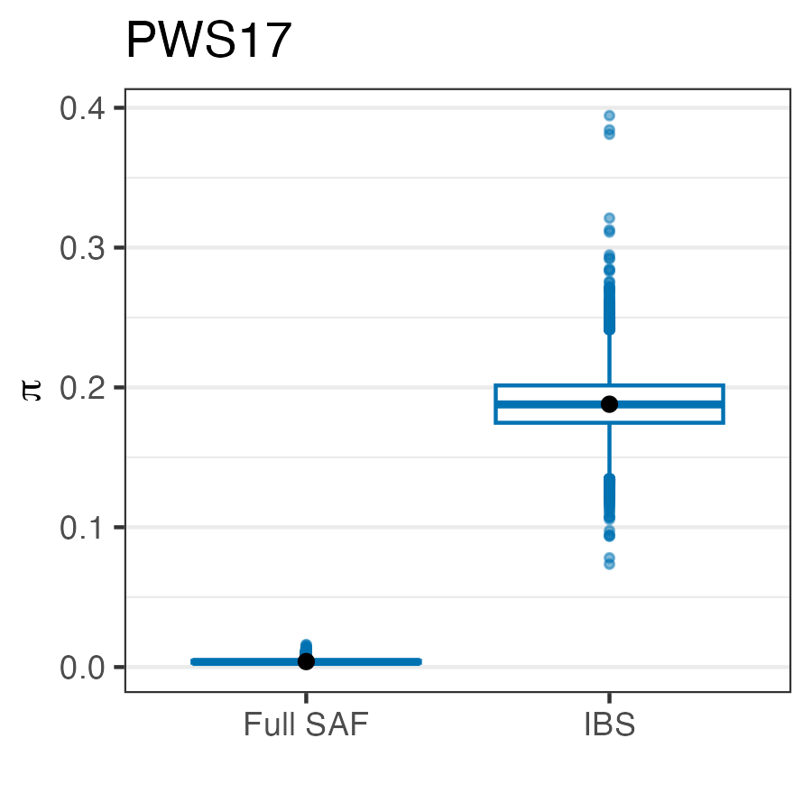

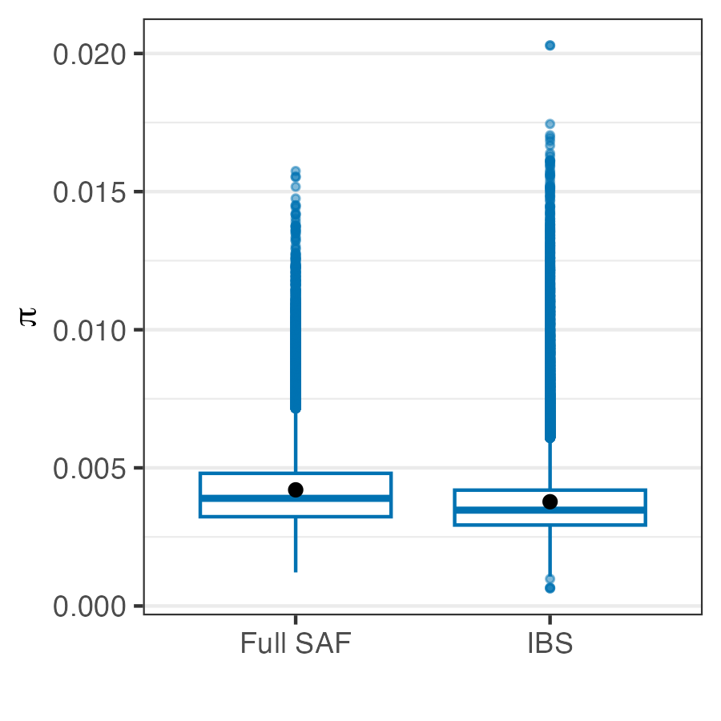

## 4.2 Tajima’s D.

```r
#Tajima's D (folded SFS)
theta<-data.frame()
for (i in 1:length(pops2)){
    theta2<-read.delim(paste0('../Data/IBS/',pops2[i],'_folded_theta_ibs_50kwin_10kstep.pestPG'))
    df<-theta2[,c("Chr","WinCenter","Tajima" )]
    df$pop<-pops2[i]
    theta<-rbind(theta, df)
}

theta$pop<-factor(theta$pop, levels=pops)
ggplot(theta, aes(x=pop, y=Tajima))+
    geom_boxplot(position=position_dodge(width = 0.8), color=org, outlier.alpha = 0.6,outlier.size = 0.7,width=0.6)+
    geom_point(stat = "summary", fun = "mean",position=position_dodge(width = 0.8))+
    ylab("Tajima's D")+xlab("")+
    theme_bw()+
    theme(panel.grid.major.x = element_blank())+
    geom_vline(xintercept = c(1.5,2.5,3.5), color="gray", size=0.5)
ggsave("../Output/SFS/TajimaD_PWS_fromBam.png", width = 5, height = 3.5)
```

[output not shown]

```r
sfiles<-list.files('../Output/SingleRead/', pattern="^Het_.+.csv.gz")

#calculate per site He

summaryHe<-data.frame(V=1:length(sfiles))
for (f in 1: length(sfiles)){
    af<-fread(paste0("../Output/SingleRead/", sfiles[f]))
    fname<-gsub("Het_",'',sfiles[f])
    fname<-gsub(".csv.gz",'', fname)

    af$het1<-af$knownEM*2*(1-af$knownEM)
    af$het2<-af$maf*2*(1-af$maf)

    write.csv(af, file=gzfile(paste0('../Output/SingleRead/',sfiles[f])))

    summaryHe$He_knownEM[f]<-mean(af$het1)
    summaryHe$He_maf[f]<-mean(af$het2, na.rm=T)
}


# set window size and window jump
window_size <- 50000
window_jump <- 10000
Chrsize<-read.delim("../Data/new_vcf/chr_sizes.bed", header = F)
names(Chrsize)<-c("chr","start","end")






for (f in 1: length(sfiles)){
    af<-fread(paste0("../Output/SingleRead/", sfiles[f]))
    fname<-gsub("MAF_",'',sfiles[f])
    fname<-gsub(".csv.gz",'', fname)
    He_windows<-data.frame()
    for (i in 1:26){
        # use seq to find the start points of each window
        window_start <- seq(from = 1, to = Chrsize$end[i], by = window_jump)
        # add the size of the window to each start point
        window_stop <- window_start + window_size-1

        window_start <- window_start[which(window_stop < Chrsize$end[i])]
        window_stop <- window_stop[which(window_stop < Chrsize$end[i])]

        # save as a data.frame
        windows <- data.frame(chr=paste0("chr",i),start = window_start, stop = window_stop,
                          mid = window_start + (window_stop-window_start)/2)


        df<-af[af$chromo==paste0("chr",i),]

        #window-based He per chromosome
        for (j in 1:nrow(windows)){
            dat<-df[df$position>=windows$start[j] & df$position<=windows$stop[j],]
            n=50000-nrow(dat)

            windows$het1[j]<-mean(c(dat$het1, rep(0, times=n)), na.rm=T)
            windows$het2[j]<-mean(c(dat$het2, rep(0, times=n)), na.rm=T)
        }

        He_windows<-rbind(He_windows, windows)

    }
    write.csv(He_windows, file=gzfile(paste0("../Output/SingleRead/Het_windowed_",fname,".csv.gz")))




for (i in 1:26){
    # use seq to find the start points of each window
    window_start <- seq(from = 1, to = Chrsize$end[i], by = window_jump)
    # add the size of the window to each start point
    window_stop <- window_start + window_size-1

    window_start <- window_start[which(window_stop < Chrsize$end[i])]
    window_stop <- window_stop[which(window_stop < Chrsize$end[i])]

    # save as a data.frame
    windows <- data.frame(chr=paste0("chr",i),start = window_start, stop = window_stop,
                      mid = window_start + (window_stop-window_start)/2)

    for ()
    df<-af3[af3$chromo==paste0("chr",i),]
    #He per chromosome
    for (j in 1:nrow(windows)){
        dat<-df[df$position>=windows$start[j] & df$position<=windows$stop[j],]
        n=50000-nrow(dat)

        windows$het1[j]<-mean(c(dat$het1, rep(0, times=n)), na.rm=T)
        windows$het2[j]<-mean(c(dat$het2, rep(0, times=n)), na.rm=T)
    }

    He_windows<-rbind(He_windows, windows)
}

## This expected heterozygosity is from the IBS data with maf >0.05. To obtain the average he, assumed all other sites were het=0 and calculated the average for 50000 base windows.

mean(He_windows$het1)
#0.004742556
mean(He_windows$het2)
#0.004360721

# stats from bcftools and calculating 2pq for PWS07 (He) was 0.01794937 (using hard called genotypes)
```

[output not shown]